# A3 - Incarceration Trends

Kara Pugh

2022-05-22

### Summary Information

In the Texas prison systems the average number of black prisoners is much **higher** than the average number of prisoners for other races with the mean for black prisoners being 363.392286 and the mean for latinx prisoners, white prisoners, Asian American/Pacific Islander prisoners, and native prisoners being 265.3819379, 217.9529633, 2.1128881, and 0.3706491 respectively. The average proportion of black prisoners compared to the total prison population (black prisoners/total prisoners) is 0.2453725 which is significantly higher than both Asian American/Pacific Islander prisoners (2.6022503^{-4}) and native prisoners (6.6170181^{-5}). But not quite as high as white prisoners (0.4316983) and latinx prisoners (0.3045436) since white and latinx make up a vast majority of the population in Texas. However, when we look at each race individually the data is no longer skewed by the larger general populations of whites and latinx and we see that African Americans are disproportionately incarcerated. Comparing the number of people from each race in prison versus that race’s overall population per county (ie. black prisoners/black population) we see that the proportion of the black population in prison is much higher than the proportion for other races. The maximum proportion of black people in prison is 0.4054054 while the maximum proportion of people in prison for white and latinx people does not even reach 0.1 even though they make up the majority of Texas’ population.

### Charts

I chose to include this chart for two reasons. First, it displays how across multiple races the number of prisoners is declining. Secondly, it visually shows how the number of black prisoners is consistently higher than the number of white prisoners. Also, I specifically chose Harris County because it is the county with the most prisoners.

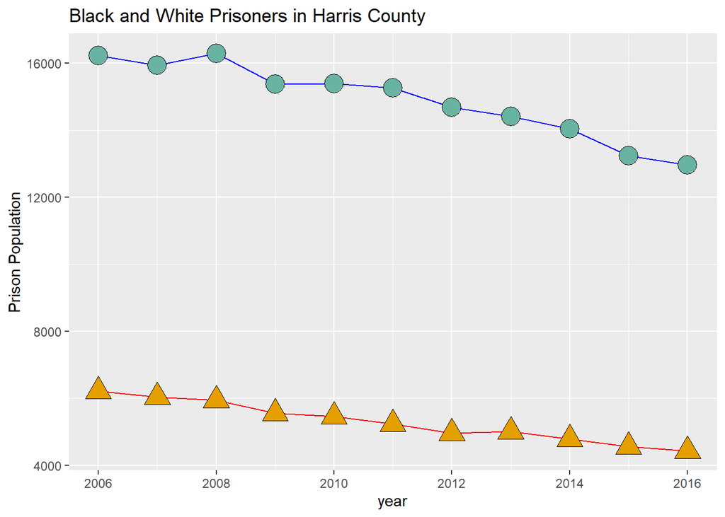

- Races
- Black = teal circle
- White = yellow triangle

I chose to include this chart because it displays how the proportion of black prisoners relates to the proportion of white prisoners in Anderson county. Also, from the chart we can see that for the most part the proportion of white people does not go past a certain level, while the proportion of black people is distributed throughout the graph.

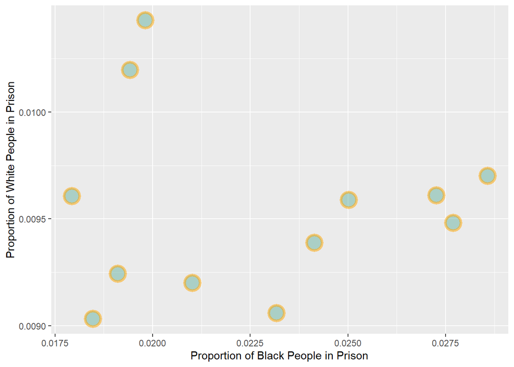

### Map

I chose to include this map because it provides a good visualization of how many black prisoners there are in each Texas county. From the map it is clear that there are some counties that have a very large number of black prisoners and some that do not have a very many. In other words, the distribution is concentrated in a few specific counties.

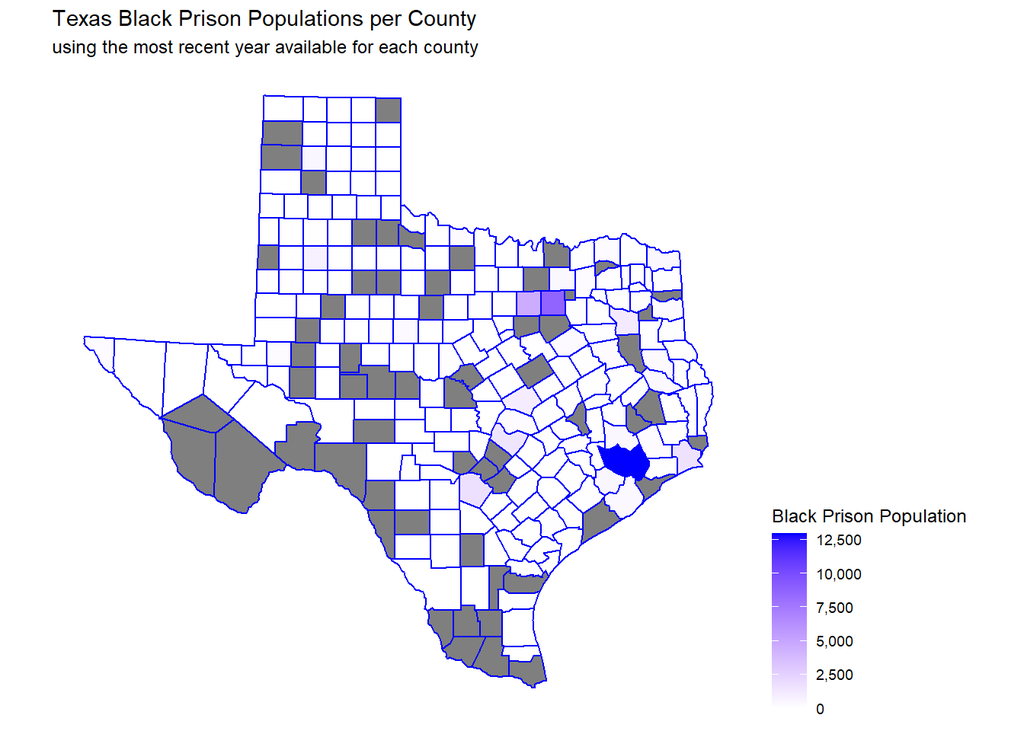